# Basics of Statistics: Session Four

Kirsten Schutter and Hugo Quené

2022-10-09

# Introduction

In session three we have discussed the association between variables, and that you can test hypotheses about associations using statistical models.

In this session we are going to test some hypotheses ourselves. We will be using the `students` data.

You have loaded this data set in Session Two, exercise 2-2.

```r
# for knitting, the full command is given here!
students <- read.csv(
  file=url("https://www.hugoquene.nl/R/students.csv") )
```

First, let’s take a closer look at the data.

```r
class(students) # gives the type of the data
```

```
## [1] "data.frame"
```

```r
str(students) # shows the structure of the variables
```

```
## 'data.frame':    115 obs. of  5 variables:
##  $ group   : int  7 7 7 7 7 7 7 7 7 7 ...
##  $ sex     : chr  "Female" "Female" "Female" "Female" ...
##  $ height  : num  174 177 168 164 163 172 159 167 195 168 ...
##  $ shoesize: num  39 39 39 38 37 40 38 38 46 39 ...
##  $ siblings: int  2 3 1 2 4 2 2 1 1 1 ...
```

We now know that `students` is a data matrix of the class `data frame`. There are 115 observations and 5 variables of which two integer variables (`group` and `siblings`), one character variable (`sex`), and two numerical variables (`height` and `shoesize`).

It is useful to transform the variable `sex` into a categorical (factor) variable.

```r
students$sex <- as.factor(students$sex)
```

When we look at the structure again, we see that `sex` is now a factor variable, with two levels: `Female` and `Male` (in alphabetical order).

```r
str(students)
```

```
## 'data.frame':    115 obs. of  5 variables:
##  $ group   : int  7 7 7 7 7 7 7 7 7 7 ...
##  $ sex     : Factor w/ 2 levels "Female","Male": 1 1 1 1 1 1 1 1 2 1 ...
##  $ height  : num  174 177 168 164 163 172 159 167 195 168 ...
##  $ shoesize: num  39 39 39 38 37 40 38 38 46 39 ...
##  $ siblings: int  2 3 1 2 4 2 2 1 1 1 ...
```

# *t* test

For the sake of argument, and demonstration, we will hypothesize that men and women have (or self-report) different shoe sizes. This is our research hypothesis. The null hypothesis claims the opposite, viz. that men and women do not have different shoe sizes. We will test the null hypothesis in two-sided fashion, and a priori we have set the risk of a Type I error at $\alpha=.05$ (false rejection of H0).

We can test for the difference between two groups with a *t* test for two independent samples. For more background, see https://hugoquene.github.io/QMS-EN/ch-testing.html#sec:ttest-indep (§13.6).

## Inspect and clean variables

Let’s take a closer look at the variables in our hypothesis: `shoesize` and `sex`.

```r
summary(students$shoesize)
```

```
##    Min. 1st Qu.  Median    Mean 3rd Qu.    Max.
##   28.00   38.00   39.00   40.26   41.00  140.00
```

```r
summary(students$sex)
```

```
## Female   Male
##     94     21
```

Since `shoezise` is a continuous (numerical) variable, the `summary` command provides different information than for the categorical variable `sex`.

Note that the numbers of female and male participants are *not* equal (not even nearly equal) in this sample. (Note: If the purpose of your study is to compare groups, then you *should* aim for groups of approximately equal size).

The `summary` of `shoesize` shows that there are at least two unlikely values: the minimum and the maximum value for `shoesize`. Although a shoe size of 28 might be possible for a very small person, a shoe size of 140 does not even exist.

Let’s further inspect this variable to see if there are any other unlikely values between 28 and 140.

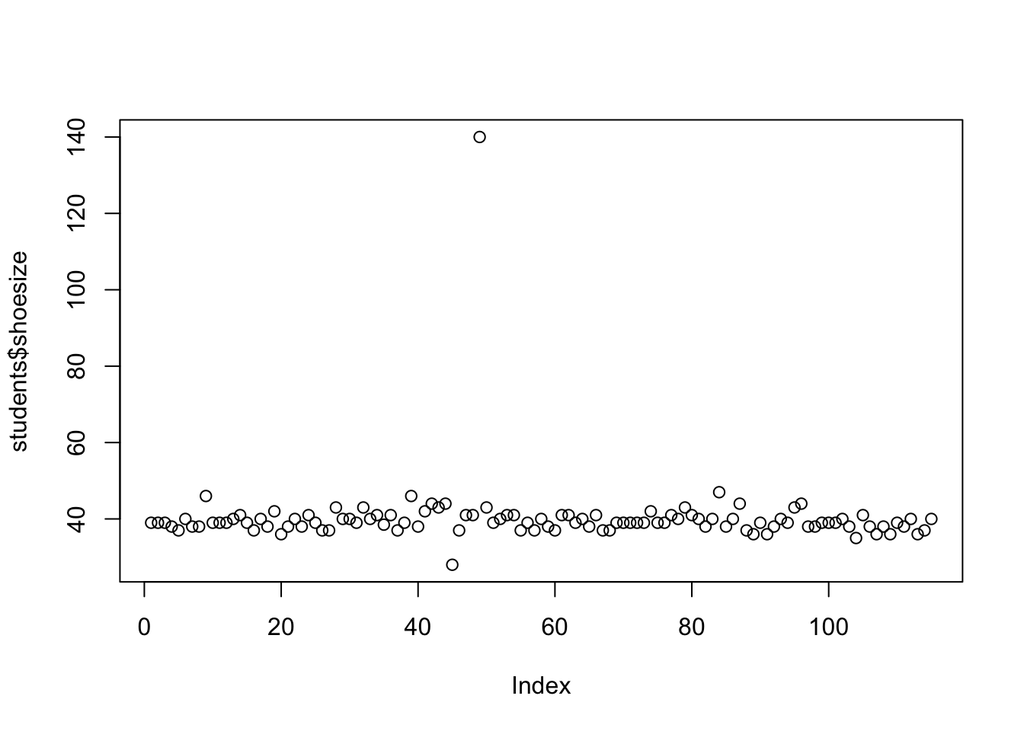

```r
plot(students$shoesize)
```

Do you see any other *outliers*?

The subject with shoe size 28 has an index number between 40 and 50 (along the X axis). Let’s inspect whether this subject also has a low value for height.

```r
students[40:50,] # shows the data in row 40 to 50
```

```
##    group    sex height shoesize siblings
## 40     8 Female    170       38        3
## 41     8   Male    172       42        1
## 42     8   Male    185       44        1
## 43     8   Male    180       43        2
## 44     8   Male    187       44        1
## 45     8 Female    175       28        2
## 46     8 Female    166       37        3
## 47     8 Female    165       41        0
## 48     8 Female    179       41        2
## 49     8 Female    171      140        4
## 50     8   Male    177       43        0
```

The observed shoe size of 28 is observed for subject 45. Her height is 175 cm. Does this seem to make sense?

We can also see that subject 49 is the one with the impossible value of 140.

Before we proceed with our statistical test, the *t* test, we remove the subjects with the unlikely values.

```r
# remove rows 45 and 49, store the result in `students`;
# note that this OVERWRITES the original contents of `students`!
students <- students[ -c(45,49), ] # minus two rows, all columns
```

Now, let’s see how this worked, by checking the dimensions of `students` again.

```r
dim(students)
```

```
## [1] 113   5
```

What changed in the dimensions here?

## Check assumptions

Every statistical test requires some underlying statistical assumptions. For the *t* test there are three assumptions:

- the data have a normal (gaussian) sampling distribution;
- the variances in both groups are approximately equal (homogeneity of variance);
- the observations are independent (i.e., sampling errors are not correlated).

### Exercise 4.1 Check for normality

First, let’s check the first assumption, whether the DV is indeed normally distributed (see Session Two). What do you conclude?

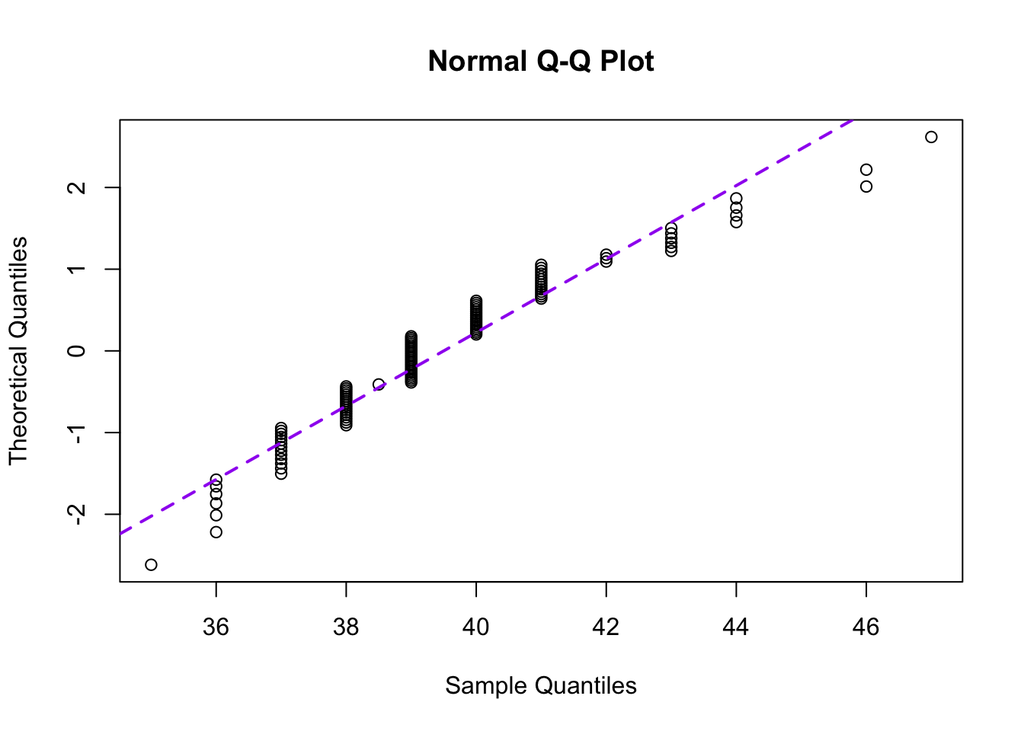

```r
qqnorm( students$shoesize, datax=T )
qqline( students$shoesize, datax=T, col="purple", lwd=2, lty=2 )
```

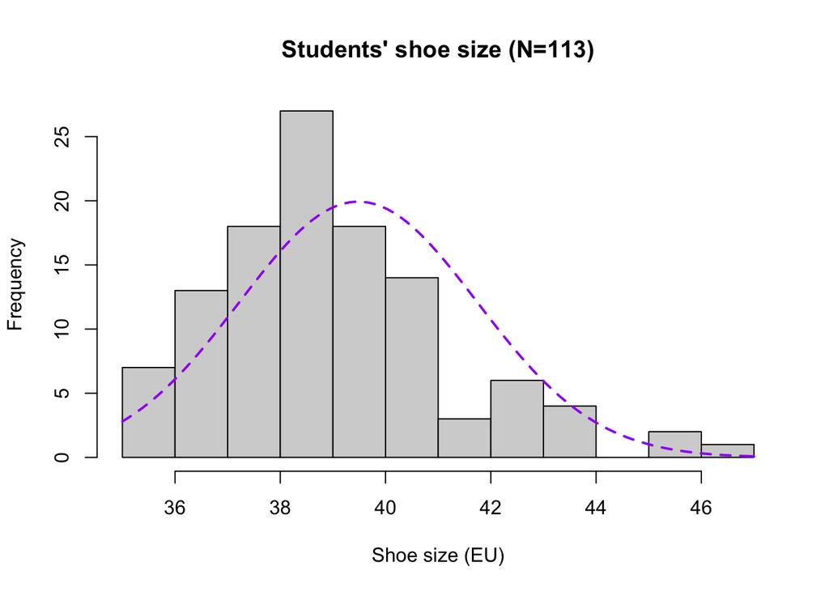

```r
with(students, hist( shoesize,
                     breaks=nclass.FD,
                     xlab="Shoe size (EU)", # axes must always be labeled
                     main="Students' shoe size (N=113)" ) ) -> students.hist
curve( dnorm(x, mean=mean(students$shoesize),
             sd=sd(students$shoesize) ) * 113*1, # multiply by N * binwidth
       add=TRUE, lty="dashed", col="purple", lwd=2 )
```

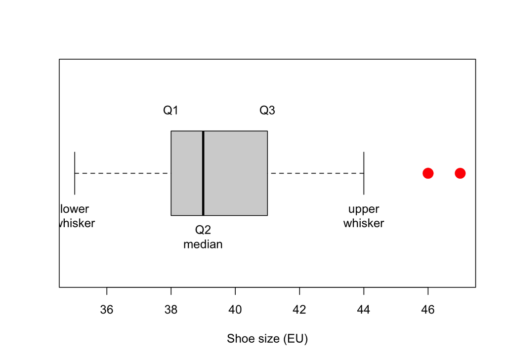

```r
with(students, boxplot( shoesize, horizontal=TRUE,
                        outpch=16, outcol="red", outcex=2, # highlight outliers
                        xlab="Shoe size (EU)" ) ) -> students.boxplot # save results
# add explanatory text
text( students.boxplot$stats[1,1], 0.8, "lower\nwhisker", adj=0.5 )
text( students.boxplot$stats[2,1], 1.3, "Q1", adj=0.5 )
text( students.boxplot$stats[3,1], 0.7, "Q2\nmedian", adj=0.5 )
text( students.boxplot$stats[4,1], 1.3, "Q3", adj=0.5 )
text( students.boxplot$stats[5,1], 0.8, "upper\nwhisker", adj=0.5 )
```

Second, let’s check the second assumption, whether the variance is homogeneous (approximately equal) in the two groups. We use the *Levene’s Test* to check for homogeneity of variances. This function is available in the `car` package.

```r
require(car) # loads the `car` package
```

If this package is not installed yet you will receive a warning message. In that case, you will have to install the `car` package first.

```r
# remove comment symbol from next line, if you need to install `car` package
# install.packages("car")
require(car) # loads the `car` package
```

Levene’s test uses the following hypotheses:

- Null hypothesis (H0): the variances of the two groups are equal.
- Alternative hypothesis (Ha): the variances are different.

```r
leveneTest( shoesize ~ sex, data=students )
```

```
## Levene's Test for Homogeneity of Variance (center = median)
##        Df F value Pr(>F)
## group   1  1.3061 0.2556
##       111
```

This indicates that there is no compelling evidence to reject the H0. The probability of finding this difference in variance, or a larger difference, if H0 is true, is $p=.26$. We may safely assume that the variances in the two groups are indeed approximately equal.

## Statistical test

After all these preliminaries we can finally run our *t* test.

The critical, first argument is the **model** tested here. By definition of the *t* test, there is a single explanatory variable (`sex`) which defines exactly two groups in the data set; `shoesize` is the dependent variable, and the variances of `shoesize` in the two groups are indeed assumed to be equal.

```r
t.test( shoesize ~ sex, data=students, var.equal=TRUE )
```

```
##
##  Two Sample t-test
##
## data:  shoesize by sex
## t = -11.128, df = 111, p-value < 2.2e-16
## alternative hypothesis: true difference in means between group Female and group Male is not equal to 0
## 95 percent confidence interval:
##  -4.952256 -3.455094
## sample estimates:
## mean in group Female   mean in group Male
##             38.70109             42.90476
```

The output of the *t* test shows us the average shoe size per group: Females have an average shoe size of 38.7 and males an average shoe size of 42.9, in these samples. The shoe sizes seem to differ between groups, but is the difference statistically significant – is the chance of finding this difference (or a larger one) smaller than the chosen $\alpha=.05$? The chance of finding this difference (or a larger one) is reported on my computer as $p < 2.2 * 10^(-16)$ which is indeed very small. The chance depends on the value of *t* (which in turn depends on the difference between the groups and on the pooled standard deviation) and on the numbers of observations (degrees of freedom). What do we conclude?

We have found a statistically significant effect, but is the effect also relevant? For this we need to know the magnitude of the effect. We can calculate the effect size expressed as *Cohen’s d*. To obtain that effect size, we need some auxiliary functions that we will not explain here.

```r
s_pooled <- function( y1, y2 ) {
  d1 <- y1[!is.na(y1)]
  d2 <- y2[!is.na(y2)]
  n1 <- length(d1)
  n2 <- length(d2)
  sd1 <- sd(d1)
  sd2 <- sd(d2)
  return( sqrt( ( (n1-1)*sd1^2 + (n2-1)*sd2^2) / (n1+n2-2) ) )
}

cohen_d <- function( y1, y2 ) {
  d1 <- y1[!is.na(y1)]
  d2 <- y2[!is.na(y2)]
  return( (mean(d1)-mean(d2))/(s_pooled(d1,d2)) )
}
```

```r
y1 <- students[ students$sex=="Male", 4 ] # select shoe size values of males and store in object y1
y2 <- students[ students$sex!="Male", 4 ] # select shoe size values of females and store in object y2

s_pooled( y1, y2 )
```

```
## [1] 1.562048
```

```r
cohen_d( y1, y2 )
```

```
## [1] 2.69113
```

The effect size of $d=2.7$ is very large: the difference is even visible to the naked eye, and without statistics. Often we study phenomena with far smaller effect sizes, e.d. $d=0.5$ or smaller, for which we really need statistics to discern the effect (signal) from the background noise.

# Correlation

We also hypothesize that students’ height and shoe size are related. Taller students tend to have larger shoe sizes as well. Both `height` and `shoesize` are measured on a continuous scale. Therefore We can test whether there is a (positive) relation between `height` and `shoesize` using Pearson Correlation.

## Exercise 4.2 Inspect the variable `height`

We have already inspected the variable `shoesize`, now inspect the variable `height`. Remove any outlier(s).

```r
# your R code goes here
```

## Visual inspection

Before we perform a correlation test, we must *always* inspect the correlation visually, in a so-called scatterplot, where the two variables constitute the coordinates. (Remember Anscombe’s illustration of misleading correlations, in Session Three!)

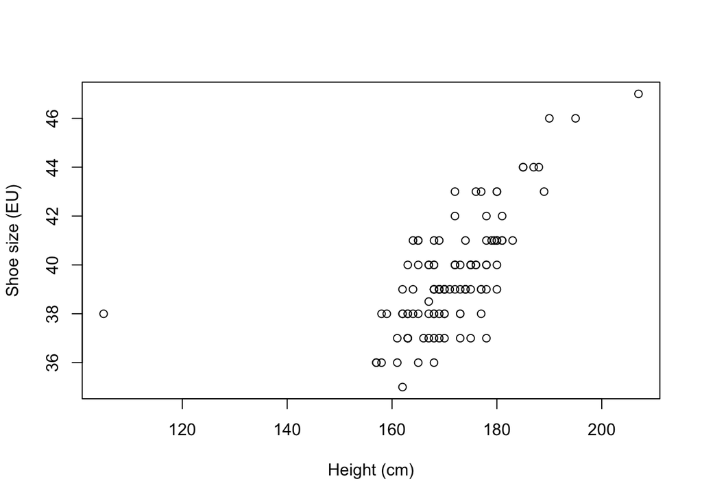

```r
plot( students$height, students$shoesize,
      xlab="Height (cm)", ylab="Shoe size (EU)")
```

Every dot represents one student’s height (X axis) and shoe size (Y axis). (Note that dots may fully overlap each other without us noticing, in this scatterplot.) Looking at the dots in this graph we may see a positive trend in the data: as X increases, so increases Y. To test whether this trend is significant, we run a correlation test using the `cor.test` function. In a correlation test, a correlation coefficient *r* is computed (this expresses the trend and amount of correlation, between -1 and +1). The H0 claims that $r=0$.

```r
cor.test( students$height, students$shoesize,
          alternative="greater", method="pearson")
```

```
##
##  Pearson's product-moment correlation
##
## data:  students$height and students$shoesize
## t = 9.0164, df = 111, p-value = 3.267e-15
## alternative hypothesis: true correlation is greater than 0
## 95 percent confidence interval:
##  0.5503063 1.0000000
## sample estimates:
##       cor
## 0.6502035
```

```r
# help(cor.test) for more information
```

Now that we know that there is a positive relationship, it would also be very informative to know more details about this relationship. Which line or curve would best describe the positive association in the scatterplot above? This is a question about the statistical model.

# Linear regression

In this section we will regard the observed data as a combination of `model` and `error`. The `model` part is the variation in the data that we try to explain or understand, using predictors and theories, while the remaining or residual part is `error` or unexplained variation in the data.

Data = model + error.

## Intercept-only model

We start out with a very simple model (see Session Three), viz. one without any predictors. The only predictor (in the `model` part) is the mean of the dependent variable Y:

$y_i = 1 \bar{Y} + \epsilon_i$

```r
mean(students$shoesize) # 39.50
```

```
## [1] 39.4823
```

```r
sd(students$shoesize) # 2.27
```

```
## [1] 2.261804
```

```r
m0 <- lm( shoesize ~ 1, data=students ) # 1 denotes intercept
# help(lm) for background
summary(m0)
```

```
##
## Call:
## lm(formula = shoesize ~ 1, data = students)
##
## Residuals:
##     Min      1Q  Median      3Q     Max
## -4.4823 -1.4823 -0.4823  1.5177  7.5177
##
## Coefficients:
##             Estimate Std. Error t value Pr(>|t|)
## (Intercept)  39.4823     0.2128   185.6   <2e-16 ***
## ---
## Signif. codes:  0 '***' 0.001 '**' 0.01 '*' 0.05 '.' 0.1 ' ' 1
##
## Residual standard error: 2.262 on 112 degrees of freedom
```

We can see here that the value of the intercept ($\bar{Y}$) is indeed equal to the sample mean of shoe size. And the standard deviation of the residuals (of$\epsilon_i$) is indeed equal to the sample standard deviation in shoe size. In other words, this model does not provide any explanation or prediction of shoesize.

## Adding a predictor

To inspect the effect of `height` we add it as a predictor to the `model` part. The first predictor is still the mean of the dependent variable Y, but now we add a second predictor X:

$y_i = 1 \bar{Y} + \beta_1 X_{1i} + \epsilon_i$

```r
m1 <- lm(  shoesize ~ 1+height, data=students )
summary(m1)
```

```
##
## Call:
## lm(formula = shoesize ~ 1 + height, data = students)
##
## Residuals:
##     Min      1Q  Median      3Q     Max
## -3.4480 -1.1684 -0.1684  0.9738  7.9312
##
## Coefficients:
##             Estimate Std. Error t value Pr(>|t|)
## (Intercept) 15.13976    2.70468   5.598 1.59e-07 ***
## height       0.14218    0.01577   9.016 6.53e-15 ***
## ---
## Signif. codes:  0 '***' 0.001 '**' 0.01 '*' 0.05 '.' 0.1 ' ' 1
##
## Residual standard error: 1.726 on 111 degrees of freedom
## Multiple R-squared:  0.4228, Adjusted R-squared:  0.4176
## F-statistic:  81.3 on 1 and 111 DF,  p-value: 6.535e-15
```

if we add predictor `height` to the model, the value of the intercept changes. It is now the expected value of `shoesize` if `height` is zero. For a person with height zero, the expected shoesize is 15. (Note that this model is fit after we have excluded two students from the data set.)

On the next line of output we find the regression coefficient ($\beta_1$) for `height`. For every unit increase of `height` shoesize will increase by 0.14. Now this is valuable information: for every 7 cm increase in `height`, the shoesize increases with $7 \times 0.14 \approx 1$ size unit. When we look at the associated p value of this coefficient, what can we conclude?

The standard deviation of the residuals (of$\epsilon_i$) is smaller in model m1 (1.726) than in model m0 (2.262). The `model` part of the data has increased and the `error` part has decreased, going from model m0 to m1.

The plot below shows the parameter estimates from this regression model. (This plot was created with the package `ggplot2` which we will not discuss further; see `help(ggplot2)` for further information and explanations.)

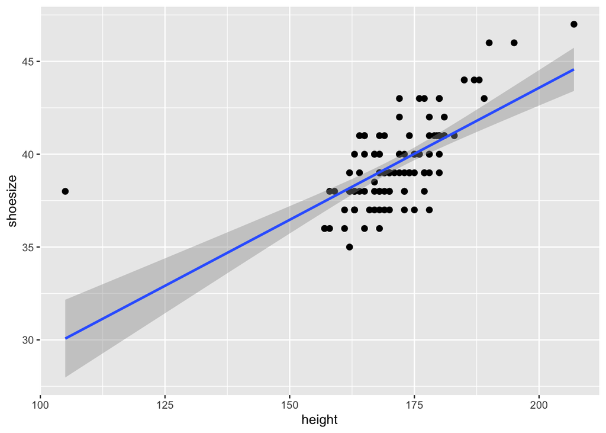

```r
require(ggplot2)
ggplot( students,
        aes(x=height, y=shoesize)) +
        geom_point(size=2) +
        geom_smooth(method=lm, se=TRUE)
```

## Centering the predictor

It is recommended to *center* your predictor(s), that is, to use relative values (relative to the sample mean of your predictor) rather than absolute values (relative to zero). This makes it easier to interpret the effects, especially if multiple predictors are used (which we will not do today).

The model remains the same.

```r
# make new var height.c
height.c <- students$height - mean(students$height)
# and add it as a column (cbind) to the current students data set
students <- cbind( students, height.c )
m2 <- lm(  shoesize ~ 1+height.c, data=students )
summary(m2)
```

```
##
## Call:
## lm(formula = shoesize ~ 1 + height.c, data = students)
##
## Residuals:
##     Min      1Q  Median      3Q     Max
## -3.4480 -1.1684 -0.1684  0.9738  7.9312
##
## Coefficients:
##             Estimate Std. Error t value Pr(>|t|)
## (Intercept) 39.48230    0.16238 243.144  < 2e-16 ***
## height.c     0.14218    0.01577   9.016 6.53e-15 ***
## ---
## Signif. codes:  0 '***' 0.001 '**' 0.01 '*' 0.05 '.' 0.1 ' ' 1
##
## Residual standard error: 1.726 on 111 degrees of freedom
## Multiple R-squared:  0.4228, Adjusted R-squared:  0.4176
## F-statistic:  81.3 on 1 and 111 DF,  p-value: 6.535e-15
```

If we add the centered predictor `height.c` to the model, the value of the intercept does not change, relative to the intercept-only model: it is in fact the expected value of `shoesize` if centered `height.c` is zero, i.e., if the student’s height equals the average height in the sample.  
For a person with average height (and hence `height.c`=0), the expected shoesize is 39.5.

Note that the results and conclusions regarding the effect of `height` on `shoesize` remain unchanged between model m1 (height uncentered) and m2 (height centered).